# Regresion

# Tarea 3.

# Regresión lineal

Análisis del Problema

El desempeño de un automóvil se puede medir de diferentes formas. Algunas comunes son la cantidad de caballos de fuerza y el rendimiento del mismo, que se puede resumir en cuantas millas puede recorrer el automóvil por cada galón de combustible que consume. Para los clientes, potenciales compradores de un automóvil, este rendimiento es importante pues puede ayudar a tomar una decisión con respecto a cuál automóvil comprar (si, por ejemplo, el cliente quiere un auto que rinda por muchas millas y pueda economizar en la compra de combustible).

Desde este punto de vista, tanto a clientes como a fabricadores de automóviles, les conviene entender cuál es la relación entre diferentes características del automóvil y su rendimiento, pues el conocer estas relaciones les puede ayudar a inferir cuál va a ser la eficiencia del vehículo a partir de ver los valores de otras características. Para fabricantes, puede ser importante conocer estas relaciones para saber cómo hacer cada modelo más eficiente con respecto al anterior.

Entendimiento de los Datos

# Ejercicios

1. Cargue el archivo auto-mpg_g.csv en una variable

```r
library(GGally)
```

```r
library(ggplot2)
library(visdat)
library(caTools)
library(lessR)
library(bestNormalize)
library(mltools)

autos <- read.csv('auto-mpg_g.csv', header = T, na.strings = '?')
```

2. Utilizando Ggpairs cree un gráfico de los atributos del dataset, observe las correlaciones entre atributos

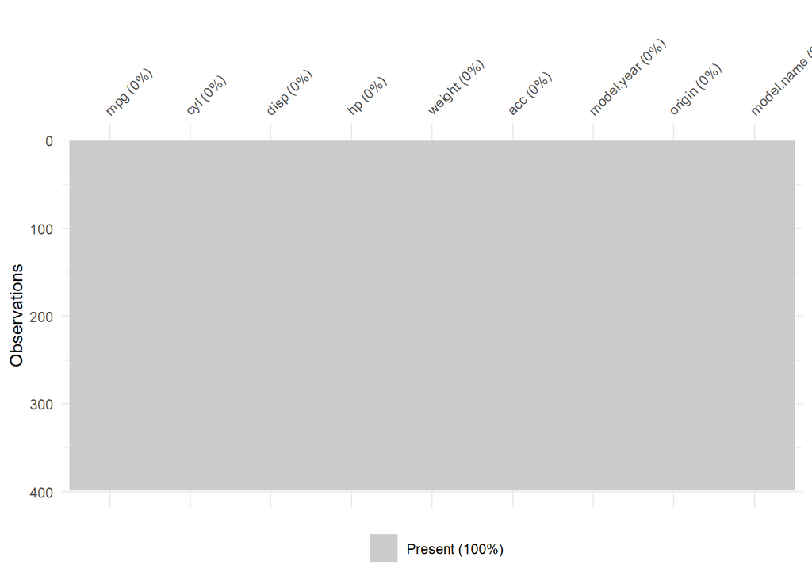

```r
vis_miss(autos) # No hay datos faltantes
```

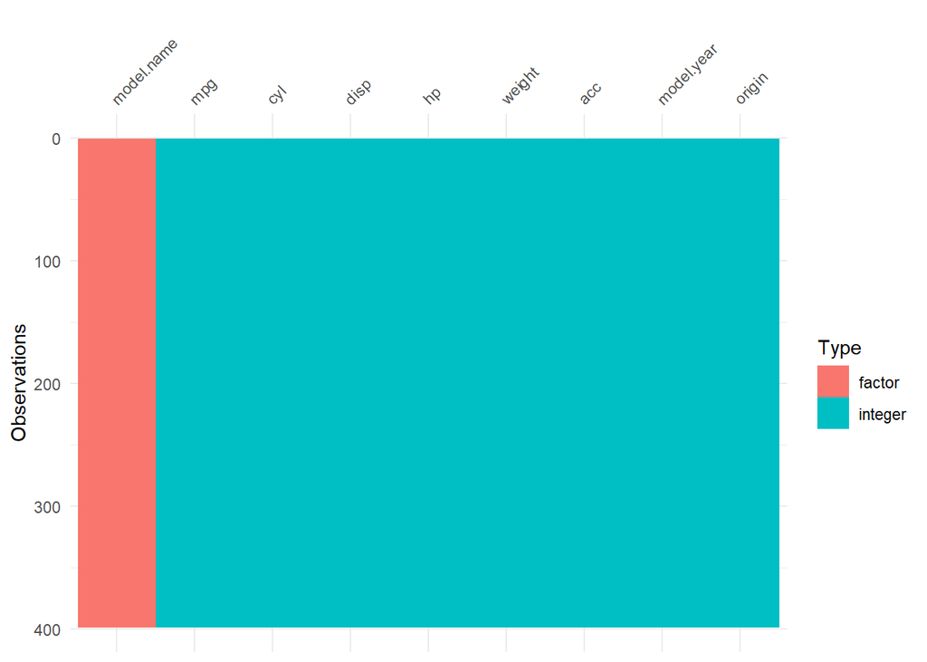

```r
vis_dat(autos)
```

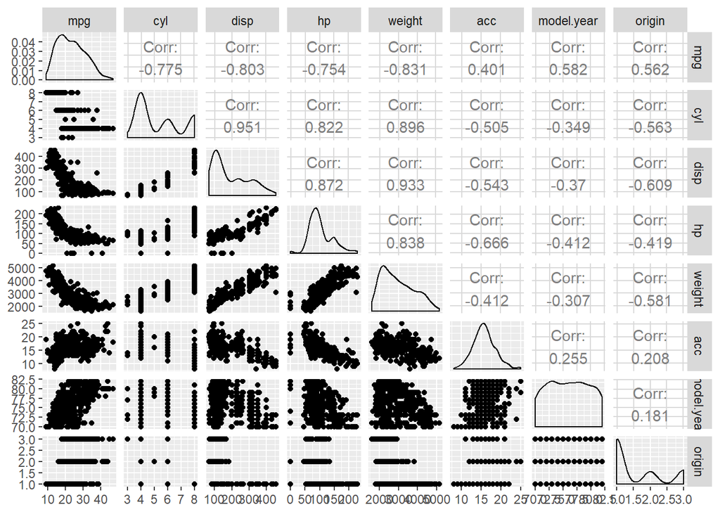

```r
autos <- autos[,1:8]
ggpairs(autos, columns = 1:8)
```

3. Separe los datos en 2 conjuntos, uno de entrenamiento y otro de pruebas. Normalmente se trabaja utilizando un 70-80% de los datos para entrenamiento y el resto para pruebas.

Recuerde fijar una semilla para que el documento sea reproducible.

Pista: https://www.rdocumentation.org/packages/caTools/versions/1.17.1/topics/sample.split

```r
autos
```

| mpg | cyl | disp | hp | weight | acc | model.year | origin |
| --- | --- | --- | --- | --- | --- | --- | --- |
| 18 | 8 | 307 | 130 | 3504 | 12 | 70 | 1 |
| 15 | 8 | 350 | 165 | 3693 | 12 | 70 | 1 |
| 18 | 8 | 318 | 150 | 3436 | 11 | 70 | 1 |
| 16 | 8 | 304 | 150 | 3433 | 12 | 70 | 1 |
| 17 | 8 | 302 | 140 | 3449 | 11 | 70 | 1 |
| 15 | 8 | 429 | 198 | 4341 | 10 | 70 | 1 |
| 14 | 8 | 454 | 220 | 4354 | 9 | 70 | 1 |
| 14 | 8 | 440 | 215 | 4312 | 9 | 70 | 1 |
| 14 | 8 | 455 | 225 | 4425 | 10 | 70 | 1 |
| 15 | 8 | 390 | 190 | 3850 | 9 | 70 | 1 |

[output cut: 388 more lines]

```r
set.seed(5)
result <- sample.split(autos, SplitRatio = .7)
autos.train <- autos[result==TRUE, ]
autos.test <- autos[result==FALSE, ]
```

4. Cree un modelo de regresion lineal utilizando el atributo mpg como la variable objetivo y en base a las correlaciones observadas en el gráfico del punto 2 escoja al menos dos atributos para usarlos como variables predictoras para el modelo.

Pista: https://www.rdocumentation.org/packages/lessR/versions/1.9.8/topics/reg

Nota: Al crear el modelo utilice el conjunto de datos de entrenamiento definido en el punto 3.

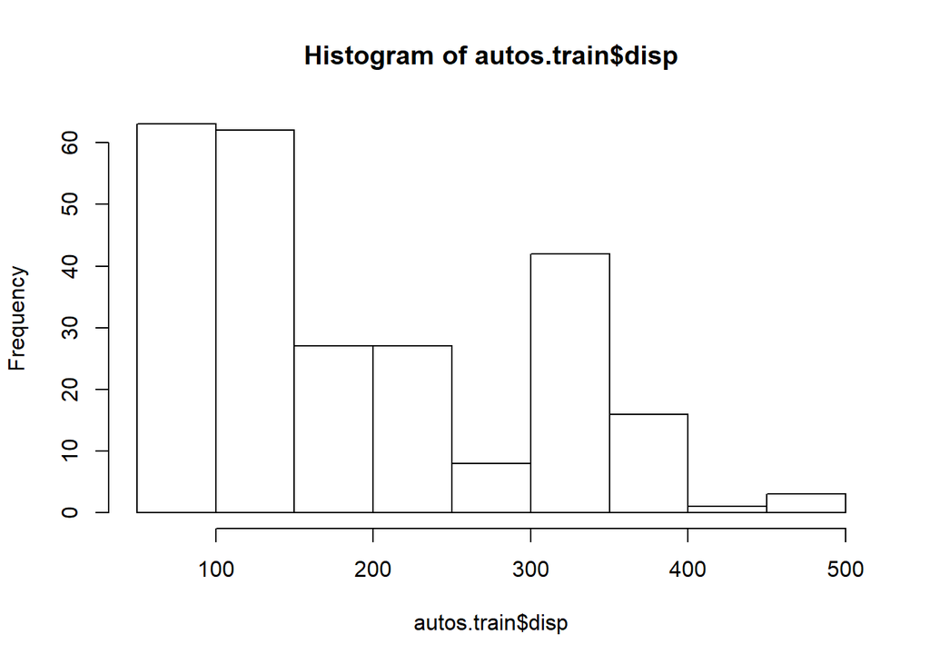

```r
#hist(log10(autos.train$disp))
#hist(log(autos.train$disp))
#hist(sqrt(autos.train$disp))
#hist(orderNorm(autos.train$disp)$x.t) # Ordered Quantile Normalization
hist(autos.train$disp)
```

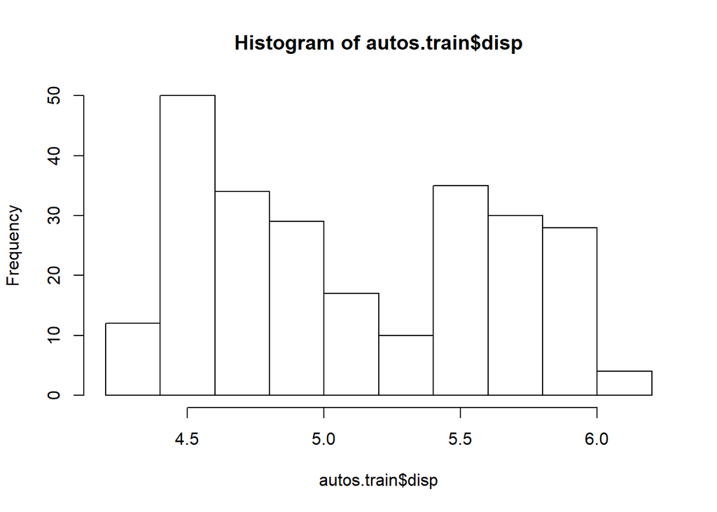

```r
autos.train$disp <- log(autos.train$disp)
hist(autos.train$disp)
```